# Income Classification

Spiridon Zarkov

2017-09-03

# Introduction

This case study will focus on modeling of a data series in order to create a classifier which is capable of accurately identifying individuals whose salary exceeds 50,000 USD. The data contains demographic information such as age, gender, education level and employment type. This report will describe the work carried out during the iterative process of data preparation, modelling and evaluation.

### Data Understanding

The data set used has 199523 rows and 42 features and a binomial label indicating a salary of less or greater than 50,000 USD, which for brevity will now be classified as `1` if over 50,000 and `0` if under 50,000 USD. The data set we will use for our analysis is 2/3 of the total data provided and a separate file containing the remaining 1/3 will be used in the end for testing.

### Preparing the R session

```r
# Import as needed
library(tidyverse)
library(pcaGoPromoter)
library(data.table)
library(caret)
library(mice)
library(DMwR)
library(ggplot2)
library(ggrepel)
library(matrixStats)
library(doParallel)
library(knitr)
library(kableExtra)
options(knitr.table.format = "html")
```

Import Data

```r
# Set Path
path <- "C:\\Users\\spiridon.zarkov\\Desktop\\Census Data\\census_income_learn.csv"
# Load in Data
train <- fread(path, header = FALSE, stringsAsFactors = TRUE)
```

As the data is all anonymized it would be better if we name each column using the information provided in our metadata file.

```r
# Assign Column Names from Metadata
colnames(train) <- c(
 "age", "class_worker",
 "ind_code",
 "occ_code",
 "education",
 "wage_per_hour",
 "hs_college",
 "marital_stat",
 "major_ind_code",
 "major_occ_code",
 "race",
 "hisp_origin",
 "sex",
 "union_member",
 "unemp_reason",
 "full_or_part_emp",
 "capital_gains",
 "capital_losses",
 "divdends_from_stocks",
 "tax_filer_stat",
 "region_prev_res",
 "state_prev_res",
 "detailed_household_family_stat",
 "detailed_household_summary_household",
 "instance_weight",
 "migration_code_msa",
 "migration_code_reg",
 "migration_code_move_reg",
 "lived_here_last_year",
 "migration_prev_sunbelt",
 "num_emp",
 "fam_under_18",
 "country_father",
 "country_mother",
 "country_self",
 "citizenship",
 "own_or_self",
 "vet_question",
 "vet_benefits",
 "weeks_worked",
 "year",
 "income"
)
```

Converting our `Income` variable to `1` if over 50,000 and `0` if under 50,000 USD

```r
# Convert Income to Class 1 if > 50,000 and 0 if less
train$class <- ifelse(train$income == "50000+.", 1, 0)
train$class <- as.factor(train$class)

# Own or Self is a factor (0, 2, 1)
train$own_or_self <- as.factor(train$own_or_self)

# Copy Train dataset to play around with
train_na <- train
train_na[train_na == "?"] <- NA
```

### Exploratory Data Analysis (EDA)

In order to decide, which features to use in the final data set for modeling, we want to get a feel for our data. And a good way to do this, is by creating different visualizations. It also helps with assessing your models later on, because to closer you are acquainted with the data’s properties, the better you’ll be able to pick up on things that might have gone wrong in your analysis (think of it as a kind of sanity-check for your data).

As usual, I want to get acquainted with the data and explore it’s properties before I begin building any model. So, I am first going to look at the distribution of target classes. We have a clear class imbalance. Over 93% of our observations are of class 0 whilst only 6% are of class 1. This will cause problems for our classifier when we begin modeling and will need to be address before that.

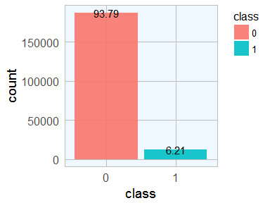

```r
# Create a custom plotting "theme"
my_theme <- function(base_size = 12, base_family = "sans"){
  theme_minimal(base_size = base_size, base_family = base_family) +
    theme(
      axis.text = element_text(size = 12),
      axis.title = element_text(size = 14),
      panel.grid.major = element_line(color = "grey"),
      panel.grid.minor = element_blank(),
      panel.background = element_rect(fill = "aliceblue"),
      strip.background = element_rect(fill = "darkgrey", color = "grey", size = 1),
      strip.text = element_text(face = "bold", size = 12, color = "white"),
      legend.position = "right",
      legend.justification = "top",
      panel.border = element_rect(color = "grey", fill = NA, size = 0.5)
    )
}

# Examine the class distributuon
# Y Axis = Count, Text = Percentage
ggplot(train_na, aes(x = class, fill = class)) +
        geom_bar(alpha = 0.9) +
        geom_text(stat='count', aes(label = round((..count..)/sum(..count..)*100, 2))) +
        my_theme()
```

How much data is missing?  
1. Some variables show close to 50% of their data missing. In this case we can either recode the “?” to a factor level or we can drop the column entirely. We have to examine our data further before deciding on an action.  
2. The variables that have under 10% missing data are usually good candidates for imputation.

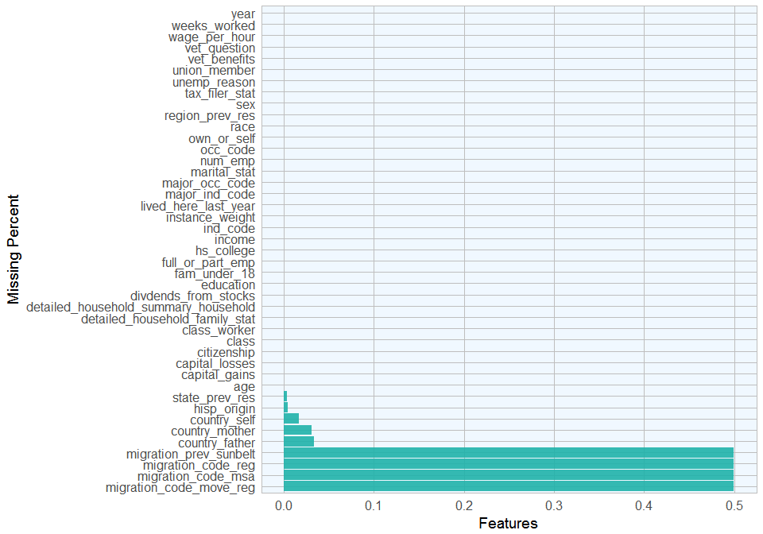

```r
missing_values <- train_na %>% summarise_all(funs(sum(is.na(.))/n()))
missing_values <- gather(missing_values, key = "feature", value = "missing_pct")
missing_values %>%
  ggplot(aes(x = reorder(feature, - missing_pct), y = missing_pct)) +
  geom_bar(stat = "identity", fill = "lightseagreen", alpha = 0.9) +
  coord_flip() +
  my_theme() +
  labs(y = "Features", x = "Missing Percent")
```

We then extract the variables that have under 10% missing data and summarise them by their countries to get a total count.

```r
# Extract missing values under 10%
miss_names <- missing_values %>%
              filter(missing_pct > 0.01 & missing_pct < 0.1) %>%
              select(feature)

# Group By Country and Summarise
name_count <- train_na %>%
              gather() %>%
              filter(key == miss_names$feature) %>%
              group_by(value) %>%
              summarise(count = n()) %>%
              arrange(desc(count))
```

Approximately 90% of our observations come from the United States. We can safely impute here without worrying about introducing too much bias in our data.

```r
# Show only top results
kable(head(name_count)) %>%
  kable_styling(bootstrap_options = "striped", full_width = F, position = "left", font_size = 15)
```

| value | count |
| --- | --- |
| United-States | 165557 |
| Mexico | 8544 |
| NA | 5377 |
| Puerto-Rico | 2163 |
| Italy | 1504 |
| Canada | 1189 |

I am also interested in how much the cases cluster in a Principal Component Analysis (PCA). We notice that the two groups are overlapping around the center. The `1` class also has significant points outside the cluster. If we want to give the cases that are very different from the rest a stronger weight, we can define a weight column where every sample outside the central PCA cluster will get a `2`. Then they will in effect be used twice in our model. This technique can help us with the class imbalance but for now we will not dig into it further.

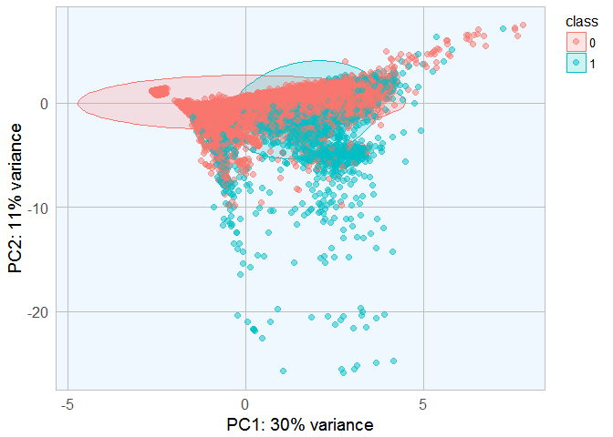

```r
# Custom Plotting "Theme" for PCA
pca_func <- function(pcaOutput2, group_name){
  centroids <- aggregate(cbind(PC1, PC2) ~ groups, pcaOutput2, mean)
  conf.rgn  <- do.call(rbind, lapply(unique(pcaOutput2$groups), function(t)
    data.frame(groups = as.character(t),
               ellipse(cov(pcaOutput2[pcaOutput2$groups == t, 1:2]),
                       centre = as.matrix(centroids[centroids$groups == t, 2:3]),
                       level = 0.95),
               stringsAsFactors = FALSE)))

  plot <- ggplot(data = pcaOutput2, aes(x = PC1, y = PC2, group = groups, color = groups)) +
    geom_polygon(data = conf.rgn, aes(fill = groups), alpha = 0.2) +
    geom_point(size = 2, alpha = 0.5) +
    labs(color = paste(group_name),
         fill = paste(group_name),
         x = paste0("PC1: ", round(pcaOutput$pov[1], digits = 2) * 100, "% variance"),
         y = paste0("PC2: ", round(pcaOutput$pov[2], digits = 2) * 100, "% variance")) +
    my_theme()

  return(plot)
}

# Keep only numeric
train_numeric <- train_na %>% keep(is.numeric)

# Apply PCA with Normalization
pcaOutput <- pca(na.omit(t(train_numeric)), printDropped = FALSE,
                 scale = TRUE, center = TRUE)

pcaOutput2 <- as.data.frame(pcaOutput$scores)

# Plot Class
pcaOutput2$groups <- train$class
pca_func(pcaOutput2, group_name = "class")
```

I also want to know what the variance is within features. Features with low variance are less likely to strongly contribute to a differentiation between the two cases.

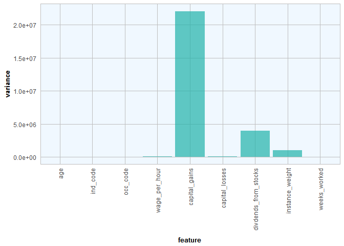

```r
# Extract Features and Variance only
colvars <- data.frame(feature = colnames(train_numeric),
                      variance = colVars(as.matrix(train_numeric)))

# Keep only High Variance
subset(colvars, variance > 50) %>%
  mutate(feature = factor(feature, levels = colnames(train_numeric))) %>%
  ggplot(aes(x = feature, y = variance)) +
  geom_bar(stat = "identity", fill = "lightseagreen", alpha = 0.7) +
  my_theme() +
  theme(axis.text.x = element_text(angle = 90, vjust = 0.5, hjust = 1)) +
  theme(axis.text=element_text(size=9),
        axis.title=element_text(size=10,face="bold"))
```

### Outlier Detection

We will test for extreme observations within each numeric feature. Variables: Age, Wage_Per_hour, Capital Gains/Losses and Dividends look like good candidates for further analysis.

```r
# Assign Class to the Numeric Values
train_numeric$class <- train$class

# Test for Outliers within each numeric value per one row
t(lapply(train_numeric[, -13], function(x) outliers::outlier(x)))
```

```
##      age ind_code occ_code wage_per_hour capital_gains capital_losses
## [1,] 90  51       46       9999          99999         4608
##      divdends_from_stocks instance_weight num_emp vet_benefits
## [1,] 99999                18656.3         6       0
##      weeks_worked year
## [1,] 52           95
```

Lets examine the distributions of these features by class.  
1. `Capital Gains/Losses`, `Dividends` and `Wages` are all clustered around a mean of `0` with some extreme outliers.  
2. `Age` variable makes sense as we would expect people with low income to be younger and people with highest income to be around the age of `50` at their peak.  
3. `Ind/Occ Code` also makes sense that class 0 is dominant around 0 as it represents cases of “Children or Not in Universe” and they will be ones most likely to be making less income.

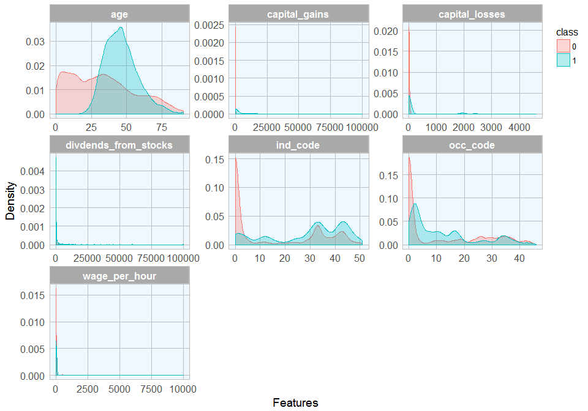

```r
gather(train_numeric, x, y, age:divdends_from_stocks) %>%
  ggplot(aes(x = y, color = class, fill = class)) +
    geom_density(alpha = 0.3) +
    facet_wrap( ~ x, scales = "free", ncol = 3) +
    labs(x = "Features", y = "Density") +
    my_theme()
```

Box-plots of features by class reveals significant outliers in `Capital Gains` as well as some observations in `Dividends` and `Wages`. We can also see that the mean of class `0` is lower in age than the mean of class `1`.

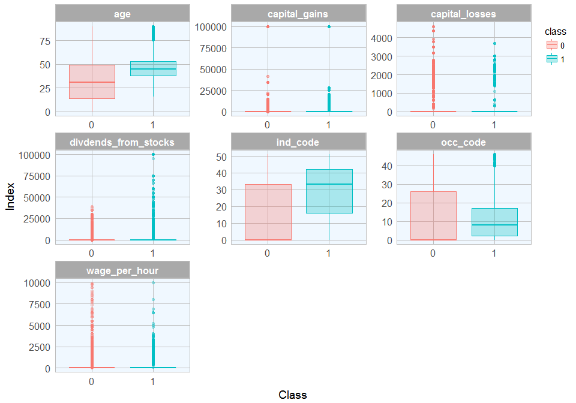

```r
gather(train_numeric, x, y, age:divdends_from_stocks) %>%
  ggplot(aes(y = y, x = class, color = class, fill = class)) +
    geom_boxplot(alpha = 0.3) +
    facet_wrap( ~ x, scales = "free", ncol = 3) +
    labs(x = "Class", y = "Index") +
    my_theme()
```

Declaring an observation as an outlier based on a just one feature could lead to unrealistic inferences. When you have to decide if an individual entity (represented by row or observation) is an extreme value or not, it better to collectively consider the features (X’s) that matter.

```r
# Build a Logistic Regression on the Numeric Values
mod <- glm(class ~ ., family=binomial, data=train_numeric)
```

Plot Extreme Values based on Cooks Distance. In general use, those observations that have a cook’s distance greater than X times the mean may be classified as influential.

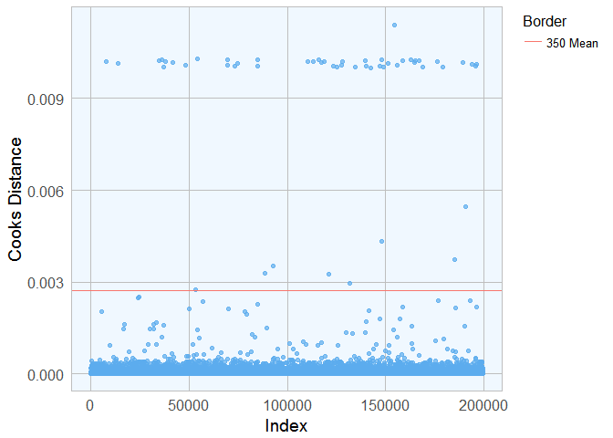

```r
# Calculate Cooks Distance
cooksd <- cooks.distance(mod)

# Make into Data Frame and Plot
cooksd_frame <- as.data.frame(cooksd)
ggplot(cooksd_frame, aes(y = cooksd, x = seq(1, length(cooksd)))) +
  geom_point(color = "steelblue2", alpha = 0.7) +
  geom_hline(aes(yintercept = 350*mean(cooksd, na.rm=T), color = "350 Mean")) +
  labs(x = "Index", y = "Cooks Distance", color = "Border") +
  my_theme()
```

Now lets find out the influential rows from the original data. If you extract and examine each influential row 1-by-1 (from below output), you will be able to reason out why that row turned out influential and deal with them accordingly. Generally, we have 3 options for dealing with outliers.  
1. Impute missing values by their Mean/Median  
2. Cap them at the IQR Range  
3. Classify them as NA and Predict on them  
There is no strict better method for choosing one option over the other.

```r
# influential row numbers (54 Total)
influential <- as.numeric(names(cooksd)[(cooksd > 350*mean(cooksd, na.rm=T))])

# Only relevant columns
train_num <- train_numeric %>% select(age, wage_per_hour, capital_gains, capital_losses,
                                      divdends_from_stocks)

# influential observations
# Again we see that "capital_gains" forms the majority of extreme outliers
# We also have a few cases from Dividends and a few from Wages Per Hour
kable(head(train_num[influential, ])) %>%
  kable_styling(bootstrap_options = "striped", full_width = F, position = "left", font_size = 15)
```

| age | wage_per_hour | capital_gains | capital_losses | divdends_from_stocks |
| --- | --- | --- | --- | --- |
| 35 | 0 | 99999 | 0 | 0 |
| 32 | 0 | 99999 | 0 | 0 |
| 37 | 0 | 99999 | 0 | 375 |
| 37 | 0 | 99999 | 0 | 0 |
| 39 | 0 | 99999 | 0 | 0 |
| 52 | 1500 | 99999 | 0 | 400 |

Setting outliers to NA based on our model analysis

```r
# Capital Gains Outlier to NA
train$capital_gains        <- ifelse(train$capital_gains == 99999, NA,
                                     train$capital_gains)

# Dividends Outlier to NA
train$divdends_from_stocks <- ifelse(train$divdends_from_stocks > 25000, NA,
                                     train$divdends_from_stocks)

# Wage Per Hour Outlier to NA
train$wage_per_hour        <- ifelse(train$wage_per_hour > 8000, NA,
                                     train$wage_per_hour)
```

Correlation Plot of Numeric Features. No feature has over 70% correlation with any others so there is no need to examine these further here.

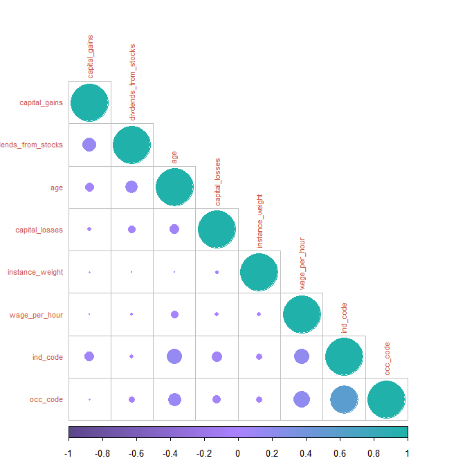

```r
train_numeric %>%
  select(age:instance_weight) %>%
  cor(use = "complete.obs") %>%
  corrplot::corrplot(type="lower", order="hclust",
                     tl.cex = 0.7, tl.col = "coral3",
                     col = colorRampPalette(c("mediumpurple4","mediumpurple1","lightseagreen"))(100))
```

### Categorical Features

We will conduct a graphical analysis of most of our categorical features and conduct any transformations that are needed before modeling.

Transform integers that should be factors.

```r
# Transform to Factors
train$num_emp      <- as.factor(train$num_emp)
train$vet_benefits <- as.factor(train$vet_benefits)
train$weeks_worked <- as.factor(train$weeks_worked)
train$year         <- as.factor(train$year)

# Create factors only dataframe for analysis
train_factors      <- train %>% keep(is.factor)
```

Here I will create two custom plotting functions to visualise my data.

```r
# Custom Graph, Custom Axis
my_bar <- function(i) {
train_factors %>%
ggplot(aes(x = i, y = class, fill = class)) +
  geom_bar(stat = "identity", alpha = 0.7) +
  labs(x = (deparse(substitute(i))), y = "Count") +
  my_theme() +
  theme(axis.text.x = element_text(angle = 90, vjust = 0.5, hjust = 1)) +
  theme(axis.text=element_text(size=9),
        axis.title=element_text(size=10,face="bold")) +
  scale_color_manual(name = "", values = c("lightseagreen", 'mediumpurple'),
                       labels = c("0", "1")) +
  scale_fill_manual(values = c("lightseagreen", 'mediumpurple'))
}

# Custom Graph, Standard Axis
my_bar_short <- function(i) {
train_factors %>%
ggplot(aes(x = i, y = class, fill = class)) +
  geom_bar(stat = "identity", alpha = 0.7) +
  labs(x = (deparse(substitute(i))), y = "Count") +
  my_theme() +
  scale_color_manual(name = "", values = c("lightseagreen", 'mediumpurple'),
                       labels = c("0", "1")) +
  scale_fill_manual(values = c("lightseagreen", 'mediumpurple'))
}
```

Large split between “Private” and “Not in Universe”.

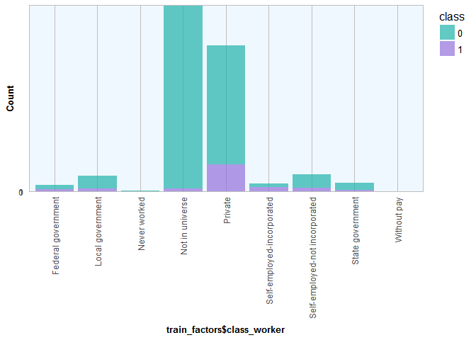

```r
my_bar(train_factors$class_worker)
```

Majority of our observations come from factor level “White”.

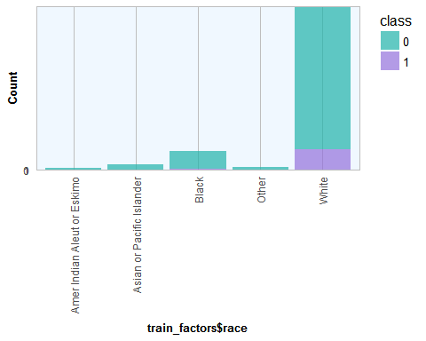

```r
my_bar(train_factors$race)
```

The total observations of men and women are evenly split.  
Males are also more likely to be high income earners.

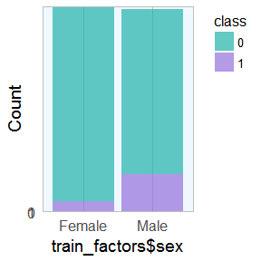

```r
my_bar_short(train_factors$sex)
```

The distributions are centered around two classes. We will factor married into one category.

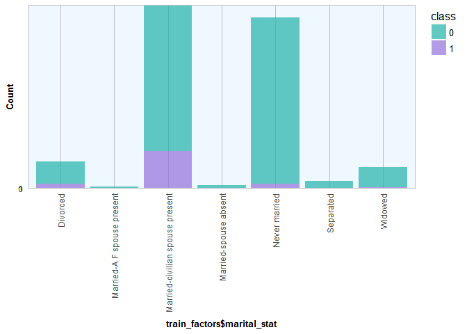

```r
my_bar(train_factors$marital_stat)
```

All variants of married will become merely married from now on.

```r
train$marital_stat <- as.character(train$marital_stat)
train$marital_stat <- if_else(train$marital_stat == "Married-civilian spouse present", "Married",
                      if_else(train$marital_stat == "Married-A F spouse present", "Married",
                      if_else(train$marital_stat == "Married-spouse absent" , "Married", train$marital_stat)))
train$marital_stat <- as.factor(train$marital_stat)
```

The two features `hs_college` and `education` contain very similar data. However, we can see that “hs_college”" shows a majority of its observations in “Not in Universe” even though “education” clearly shows us large observations with high school and bachelor level education. The integrity of “hs_college” is likely compromised and the heavy distribution of “Not in Universe” makes this feature useless to us.

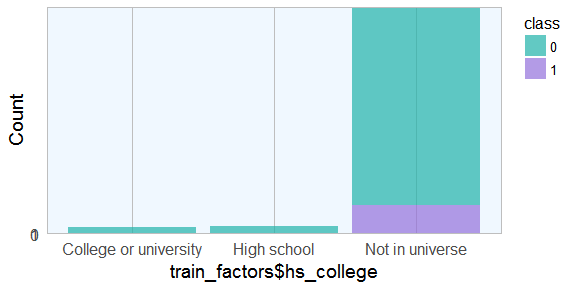

```r
my_bar_short(train_factors$hs_college)
```

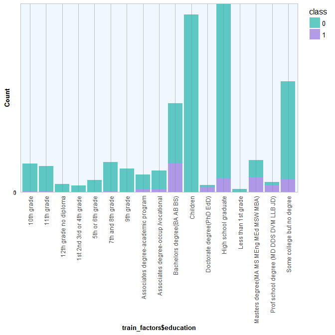

```r
my_bar(train_factors$education)
```

High earners tend to be houseowners and spouses of houseowners

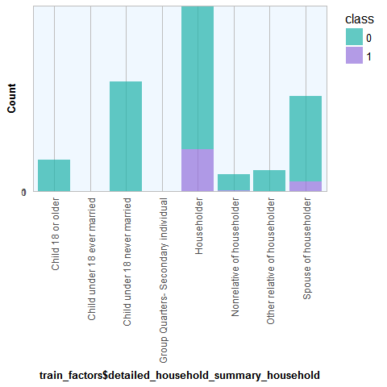

```r
my_bar(train_factors$detailed_household_summary_household)
```

#### Missing Distribution

`Not in Universe` seem to be heavily distributed in some of our factors. This data may as well be `NA` or `Missing`. We will transform all “Not in universe” characters to NA and check how our total percent missing looks after this transformation. The graph now shows that some features are nearly 100% NA. We will drop all columns over 55% missing values as they add nothing to our classifier. Luckily, the remaining series all contain one factor level that makes up around 90% of the data. This allows us to convert all NA values to that one factor level, as to not lose the relevant data from other columns, and still maintain integrity of our data.

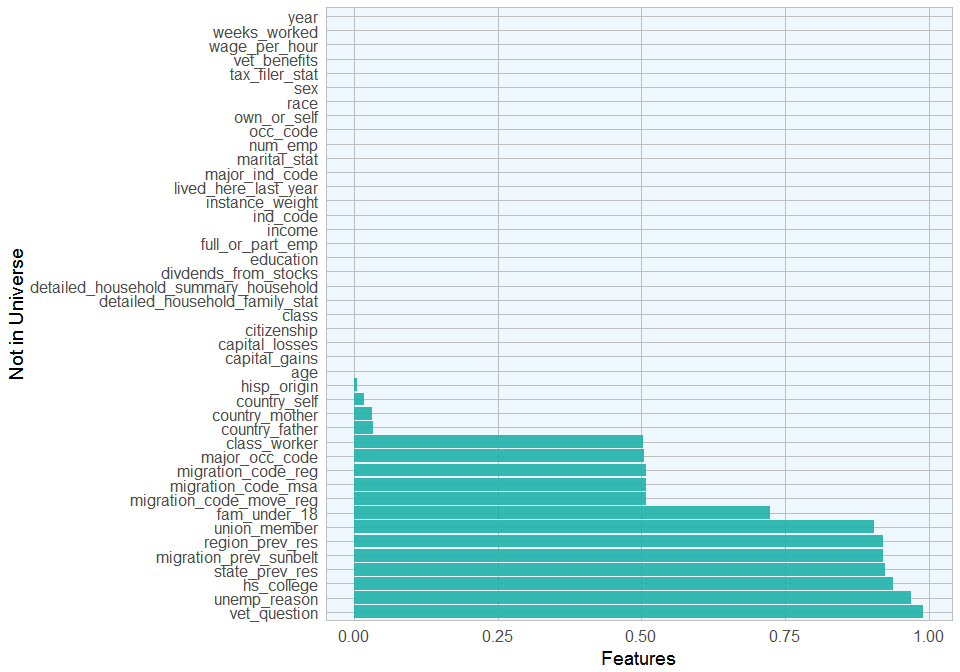

```r
train_not <- train_na
train_not[train_not == "Not in universe"] <- NA
train_not[train_not == "?"] <- NA

ma <- train_not %>% summarise_all(funs(sum(is.na(.))/n()))
ma <- gather(ma, key = "feature", value = "missing_pct")
ma %>%
  ggplot(aes(x = reorder(feature, - missing_pct), y = missing_pct)) +
  geom_bar(stat = "identity", fill = "lightseagreen", alpha = 0.9) +
  coord_flip() +
  my_theme() +
  labs(y = "Features", x = "Not in Universe")
```

We drop all features above 55% missing.

```r
# Filter 55% and Above
ma_only <- ma %>% filter(missing_pct > 0.55)
ma_only <- ma_only$feature

# Drop all with missing percent 55% and above
train <- train[, !(names(train) %in% ma_only), with = FALSE]
```

As the majority of observations outside of “Not in Universe” were “Nonmover”, we will reclassify all “NA” to level “Nonmover”. Additionally, we will reclassify Worker Class to “Private”, Country Origins to USA, Hispanic Origins to “All Other” and Major Occ Code to “Other”. This aggregation method is intended to be fast. My concern here would be in overfitting our data with too good predictors.

```r
# All Not in Universe and ? turn into NA
train[train == "Not in universe"] <- NA
train[train == "?"] <- NA

# Change all factors to character
train <- train %>% mutate_if(is.factor, as.character)

# If "NA" make into "Nonmover"
train$migration_code_move_reg <- ifelse(is.na(train$migration_code_move_reg), "Nonmover",
                                        train$migration_code_move_reg)
train$migration_code_msa      <- ifelse(is.na(train$migration_code_msa), "Nonmover",
                                        train$migration_code_msa)
train$migration_code_reg      <- ifelse(is.na(train$migration_code_reg), "Nonmover",
                                        train$migration_code_reg)

# If "NA" make into "Private"
train$class_worker            <- ifelse(is.na(train$class_worker), "Private",
                                        train$class_worker)

# If "NA" make into "United States"
train$country_father          <- ifelse(is.na(train$country_father), "United-States",
                                        train$country_father)
train$country_mother          <- ifelse(is.na(train$country_mother), "United-States",
                                        train$country_mother)
train$country_self            <- ifelse(is.na(train$country_self), "United-States",
                                        train$country_self)

# If "NA" make into "All Other"
train$hisp_origin             <- ifelse(is.na(train$hisp_origin), "All other",
                                        train$hisp_origin)

# If "NA" make into "Other"
train$major_occ_code          <- ifelse(is.na(train$major_occ_code), "Other",
                                        train$major_occ_code)

# Change all characters back to factors
train <- train %>% mutate_if(is.character, as.factor)
```

#### Imputing Data

Missing values are imputed with the mice package. MICE works by creating multiple imputations as compared to a single imputation (such as mean) takes care of uncertainty in missing values.

```r
# Features to impute
train_cols <- c("wage_per_hour", "capital_gains", "divdends_from_stocks")

# Impute missing data
dataset_impute <- mice(train[, train_cols],  print = FALSE)
train <- cbind(train[, !(names(train) %in% train_cols), drop = FALSE], mice::complete(dataset_impute, 1))
```

#### Imbalanced Class

Conventional algorithms are often biased towards the majority class because their loss functions attempt to optimize quantities such as error rate, not taking the data distribution into consideration. In the worst case, minority examples are treated as outliers of the majority class and ignored. The learning algorithm simply generates a trivial classifier that classifies every example as the majority class.

#### Handling Imbalanced Data

Outline of useful appraoches listed approximately in order of effort:

1. Do nothing. Sometimes we can train on the so-called natural (or stratified) distribution and sometimes it works without need for modification.
2. Balance the training set in some way:
   - Oversample the minority class
   - Undersample the majority class
   - Synthesize new minority class
3. Throw away minority examples and switch to an anomaly detection framework.

For our case we will try to balance our class by using a “Synthetic Minority Oversampling Technique” system. The SMOTE algorithm creates artificial data based on feature space similarities from minority samples. We can say, it generates a random set of minority class observations to shift the classifier learning bias towards minority class. To generate artificial data, SMOTE uses bootstrapping and k-nearest neighbors. The reason for using SMOTE was to strike a balance between speed and simplest while still generating a model with the highest true positive and true negative rates.

```r
# Partition data
set.seed(42)
index <- createDataPartition(train$class, p = 0.85, list = FALSE)
train_data <- train[index, ]
test_data  <- train[-index, ]

# Apply SMOTE
set.seed(9560)
smote_train <- SMOTE(class ~ ., data  = train_data)
```

Plot new distribution

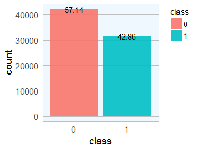

```r
ggplot(smote_train, aes(x = class, fill = class)) +
        geom_bar(alpha = 0.9) +
        geom_text(stat='count', aes(label = round((..count..)/sum(..count..)*100, 2))) +
        my_theme()
```

### Modeling

Since I’ll be using the H2O Library I will convert from an R Dataframe to an H2O Dataframe and boot up the library. I will also tell it to use all my CPU cores and allocate 26GBs of RAM to boost performance.

```r
library(h2o)
h2o.init(nthreads = -1, max_mem_size = "26G")
h2o.no_progress()
```

Now we can use the h2o.splitFrame() function to split the data into training and validation data. Here, I am using 85% for training and 15% for validation. (We already have test set from earlier). We could also just split the data into two sections, a training and test set but when we have sufficient samples, it is a good idea to evaluate model performance on an independent test set on top of training with a validation set. Because we can easily overfit a model, we want to get an idea about how generalizable it is - this we can only assess by looking at how well it works on previously unknown data.

```r
train_h2o <- as.h2o(smote_train)
test_h2o <- as.h2o(test_data)
splits <- h2o.splitFrame(train_h2o, ratios = 0.85, seed = 1)

# Train and Validation Sets
train_h2o <- splits[[1]]
valid_h2o <- splits[[2]]

# Define Response Class and Features
response <- "class"
features <- setdiff(colnames(train_h2o), c(response, "income"))

# Define as Factor
train_h2o[,response] <- h2o.asfactor(train_h2o[,response])
valid_h2o[,response] <- h2o.asfactor(valid_h2o[,response])
test_h2o[,response]  <- h2o.asfactor(test_h2o[,response])
```

#### Generalized Linear Model

The generalized linear model (GLM) is a flexible generalization of the ordinary linear regression that allows for response variables that have error distribution models other than a normal distribution. In our case, the “Binomial” family or Logistic regression will output a probability that the given input point belongs to a certain class (0 or 1). The `h2o` library has a number of advantages for us. In this scenario, it will automatically normalize our numeric features and it will encode our categorical features.

```r
glm_fit <- h2o.glm( x = features,
                    y = response,
                    training_frame = train_h2o,
                    model_id = "glm_fit",
                    validation_frame = valid_h2o, # Validation Frame
                    family = "binomial",
                    nfolds = 25,
                    seed = 1,
                    lambda_search = TRUE) # Auto tune l1/l2 parameter

# Save Model
h2o.saveModel(glm_fit, path="dl_grid", force = TRUE)
```

```r
# Load Model
glm_fit <- h2o.loadModel("C:\\Users\\spiridon.zarkov\\Desktop\\Income-Classification\\dl_grid\\glm_fit")
```

```r
# Check Performance against Test Set
glm_perf <- h2o.performance(model = glm_fit,
                            newdata = test_h2o)
```

Performance Metrics. Class 1 had an error rate of around 38%.

```r
h2o.mean_per_class_error(glm_perf); h2o.auc(glm_perf); h2o.confusionMatrix(glm_perf)
```

```
## [1] 0.2132848
```

```
## [1] 0.9314435
```

```
## Confusion Matrix (vertical: actual; across: predicted)  for max f1 @ threshold = 0.680049358625793:
##            0    1    Error         Rate
## 0      26784 1287 0.045848  =1287/28071
## 1        707 1150 0.380722    =707/1857
## Totals 27491 2437 0.066627  =1994/29928
```

Variable Importance  
We can see key levels that give us the most predictive power in our GLM model.

```r
glm_fit@model$standardized_coefficient_magnitudes
```

```
## Standardized Coefficient Magnitudes: standardized coefficient magnitudes
##                                              names coefficients sign
## 1 education.Prof school degree (MD DDS DVM LLB JD)     3.144125  POS
## 2              education.Doctorate degree(PhD EdD)     2.248803  POS
## 3                 race.Amer Indian Aleut or Eskimo     2.039583  POS
## 4                              country_self.Canada     1.855870  POS
## 5                           country_mother.England     1.767124  POS
##
## ---
##                       names coefficients sign
## 368               num_emp.5     0.000000  POS
## 369              race.Other     0.000000  POS
## 370              race.White     0.000000  POS
## 371           own_or_self.0     0.000000  POS
## 372          vet_benefits.2     0.000000  POS
## 373 lived_here_last_year.No     0.000000  POS
```

### Random Forest

Random forest is an ensemble algorithm of a Decision Tree, meaning more than one model is made, and their results used together, the aim being to cope better with unseen situations (i.e., to avoid overfitting). The idea behind random forest is to have lots of trees. Then, when you use it to predict on new data, you give the new data to each of those trees and ask each for their prediction. Since its classification we choose the most popular answer.

#### Tuning Parameters

Control how big our Random Forest will be. We will build a quick and simplistic model.

```r
# Keeping things simple
hyper_params <- list(
                     ntrees = c(25, 50, 75, 100), # Max Tree Number
                     max_depth = c(10, 20, 30), # Simplistic Model
                     min_rows = c(1, 3, 5) # Training per Leaf
                     )
```

Control the search criteria. We will run a quick search strategy instead of an exhaustive one of all parameter combinations and limit our runtime to stop if the performance metric hasn’t increased for 5 consecutive rounds by 0.05 percent.

```r
search_criteria <- list(
                        strategy = "RandomDiscrete", # Quick Search
                        max_models = 50, # Max Models
                        max_runtime_secs = 360, # Max Runtime
                        stopping_rounds = 5, # Stopping Metric
                        stopping_metric = "mean_per_class_error", # Metric
                        stopping_tolerance = 0.0005, # Stopping Metric
                        seed = 42
                        )
```

Build the model

```r
rf_grid <- h2o.grid(algorithm = "randomForest",
                    x = features,
                    y = response,
                    grid_id = "rf_grid",
                    training_frame = train_h2o,
                    validation_frame = valid_h2o,
                    nfolds = 25,
                    fold_assignment = "Stratified",
                    hyper_params = hyper_params,
                    search_criteria = search_criteria,
                    seed = 42
                    )
# Get Best Model
rf_gridperf  <- h2o.getGrid(grid_id = "rf_grid",
                             sort_by = "mean_per_class_error",
                             decreasing = FALSE)
best_rf_model_id <- rf_gridperf@model_ids[[1]]
best_rf <- h2o.getModel(best_rf_model_id)

# Save Model
h2o.saveModel(best_rf, path="dl_grid", force = TRUE)
```

```r
# Load Model
best_rf <- h2o.loadModel("C:\\Users\\spiridon.zarkov\\Desktop\\Income-Classification\\dl_grid\\rf_grid_model_0")
```

```r
# Check performance against test set
rf_perf <- h2o.performance(model = best_rf,
                           newdata = test_h2o)
```

Variable Importance  
The features Random Forest uses are different than the GLM model and we don’t need to encode our factor levels.

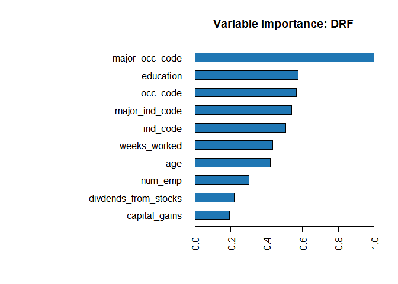

```r
h2o.varimp_plot(best_rf)
```

Our Random Forest model did worse than our GLM. Class 1 had an error rate of around 45%.

```r
h2o.mean_per_class_error(rf_perf); h2o.auc(rf_perf); h2o.confusionMatrix(rf_perf)
```

```
## [1] 0.2399797
```

```
## [1] 0.93995
```

```
## Confusion Matrix (vertical: actual; across: predicted)  for max f1 @ threshold = 0.723355095628577:
##            0    1    Error         Rate
## 0      27326  745 0.026540   =745/28071
## 1        842 1015 0.453419    =842/1857
## Totals 28168 1760 0.053027  =1587/29928
```

### Deep Learning

Deep neural networks we will use are feed-forward, which means that each layer feeds its output to subsequent layers. They are also called multilayer perceptrons (MLPs).

#### Grid Search

We can use the h2o.grid() function to perform a Random Grid Search (RGS). We could also test all possible combinations of parameters with Cartesian Grid or exhaustive search, but RGS is much faster when we have a large number of possible combinations and usually finds sufficiently accurate models.

For RGS, we first define a set of hyper-parameters and search criteria to fine-tune our models. Because there are many hyper-parameters, each with a range of possible values, we want to find an (ideally) optimal combination to maximize our model’s accuracy. We can also specify how long we want to run the grid search for. Based on the results of each model tested in the grid, we can choose the one with the highest accuracy or best performance for the question on hand.

#### Tuning

A quick walkthrough over some of the main tuning parameters:

`Adaptive learning rate:` For deep learning with h2o, we by default use stochastic gradient descent optimization with an an adaptive learning rate. The two corresponding parameters rho and epsilon help us find global (or near enough) optima.

`Activation function:` The activation function defines the node output relative to a given set of inputs. We want our activation function to be non-linear and continuously differentiable.

`Hidden nodes:` Defines the number of hidden layers and the number of nodes per layer.

`Epochs:` Increasing the number of epochs (one full training cycle on all training samples) can increase model performance, but we also run the risk of overfitting. To determine the optimal number of epochs, we need to use early stopping.

`L1:` lets only strong weights survive  
`L2:` prevents any single weight from getting too big.

`rho:` similar to prior weight updates  
`epsilon:` prevents getting stuck in local optima

```r
# Hyper Parameters
hyper_params <- list(activation = c("Rectifier", "Maxout", "Tanh",
                                    "RectifierWithDropout", "MaxoutWithDropout",
                                    "TanhWithDropout"),
                     hidden = list(c(5, 5, 5, 5, 5), c(10, 10, 10, 10),
                                   c(50, 50, 50), c(100, 100, 100)),
                     epochs = c(50, 100, 200),
                     l1 = c(0, 0.00001, 0.0001),
                     l2 = c(0, 0.00001, 0.0001),
                     rate = c(0, 01, 0.005, 0.001),
                     rate_annealing = c(1e-8, 1e-7, 1e-6),
                     rho = c(0.9, 0.95, 0.99, 0.999),
                     epsilon = c(1e-10, 1e-8, 1e-6, 1e-4),
                     momentum_start = c(0, 0.5),
                     momentum_stable = c(0.99, 0.5, 0),
                     input_dropout_ratio = c(0, 0.1, 0.2),
                     max_w2 = c(10, 100, 1000, 3.4028235e+38),
                     balance_classes = c(TRUE, FALSE)
                     )
# Search Parameters
search_criteria <- list(strategy = "RandomDiscrete",
                        max_models = 100,
                        max_runtime_secs = 900,
                        stopping_tolerance = 0.001,
                        stopping_rounds = 15,
                        seed = 42)
```

Build a Deep Learning Network

```r
dl_grid <- h2o.grid(algorithm = "deeplearning",
                    x = features,
                    y = response,
                    weights_column = weights,
                    grid_id = "dl_grid",
                    training_frame = train_h2o,
                    validation_frame = valid_h2o,
                    nfolds = 25,
                    fold_assignment = "Modulo",
                    hyper_params = hyper_params,
                    search_criteria = search_criteria,
                    seed = 42
                    )

# Get Best Model
dl_grid_model  <- h2o.getGrid(grid_id = "dl_grid",
                             sort_by = "mean_per_class_error",
                             decreasing = FALSE)

dl_grid_one <- dl_grid_model@model_ids[[1]]
dl_model_one <- h2o.getModel(dl_grid_one)

# Save best model
h2o.saveModel(dl_model_one, path="dl_grid_model", force = TRUE)
```

Load saved model (Saves time)

```r
dl_best <- h2o.loadModel("C:\\Users\\spiridon.zarkov\\Desktop\\Income-Classification\\dl_grid\\dl_grid_model_0")
```

Check performance against test set

```r
dl_perf <- h2o.performance(model = dl_best,
                           newdata = test_h2o)
```

The DL model did slightly better by reducing the Class 1 error rate to 0.35 from GLMs 0.38 but I would prefer a more significant decrease.

```r
h2o.confusionMatrix(dl_perf)
```

```
## Confusion Matrix (vertical: actual; across: predicted)  for max f1 @ threshold = 0.998522832841511:
##            0    1    Error         Rate
## 0      26714 1357 0.048342  =1357/28071
## 1        657 1200 0.353796    =657/1857
## Totals 27371 2557 0.067295  =2014/29928
```

Useful to check if we are overfitting or underfitting our with the validation frame

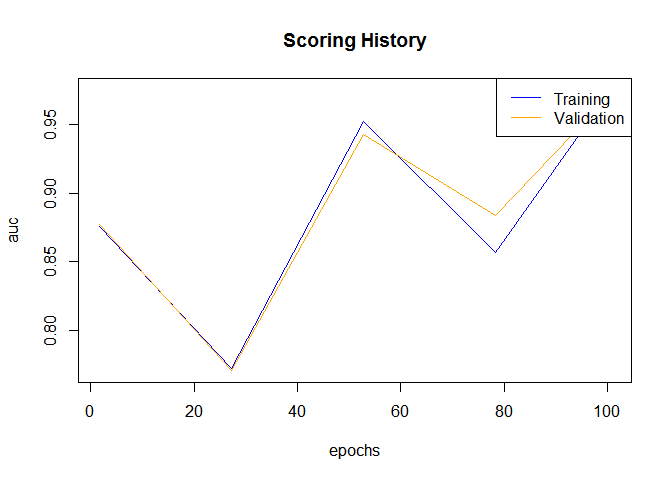

```r
plot(dl_best,
     timestep = "epochs",
     metric = "AUC")
```

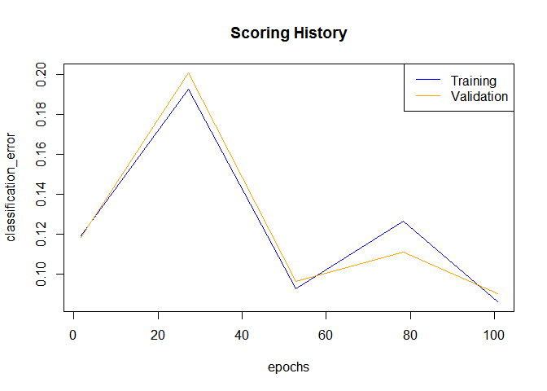

```r
plot(dl_best,
     timestep = "epochs",
     metric = "classification_error")
```

Staying within this framework we can try a few more things:  
1. New models to see how they would perform such as SVM with Cost Classifier, XGBoost with Hyper Parameter Tuning, etc. 2. We can also go back and make some modifications to our features such as adding “Weights” to our Class 1 based on our PCA analysis.  
3. Further tuning of our DL (Pre-Training, Weights) and RF (Complex Forest)

### Testing Model

Import Test Data

```r
# Set Path
path_test <- "C:\\Users\\spiridon.zarkov\\Desktop\\Census Data\\census_income_test.csv"
# Load in Data
test <- fread(path_test, header = FALSE, stringsAsFactors = TRUE)
```

Glimpse at our test series

```r
glimpse(test)
```

[output not shown]

[output cut: 21 more lines]

Lets check the class distribution of our test series

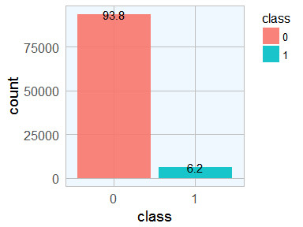

```r
ggplot(test, aes(x = class, fill = class)) +
        geom_bar(alpha = 0.9) +
        geom_text(stat='count', aes(label = round((..count..)/sum(..count..)*100, 2))) +
        my_theme()
```

Convert our test set to h2o frames.

```r
# Conver test to H2O
test_h2o <- as.h2o(test)

# As Factor
test_h2o[,response]  <- h2o.asfactor(test_h2o[,response])
```

Build our final model. Everything remains the same as before but this time we will test on our new data. We decided to use the GLM in this scenario as it performed well and its the most interpretable.

```r
glm_perf <- h2o.performance(model = glm_fit,
                            newdata = test_h2o)
```

Error rate on our Class 1 remained similar to our initial model at around 38%.

```r
h2o.auc(glm_perf); h2o.confusionMatrix(glm_perf)
```

```
## [1] 0.9339251
```

```
## Confusion Matrix (vertical: actual; across: predicted)  for max f1 @ threshold = 0.671923274147434:
##            0    1    Error         Rate
## 0      89302 4274 0.045674  =4274/93576
## 1       2364 3822 0.382153   =2364/6186
## Totals 91666 8096 0.066538  =6638/99762
```

```r
finalRf_predictions <- data.frame(actual = as.vector(test_h2o$class),
                                  as.data.frame(h2o.predict(object = glm_fit,
                                                            newdata = test_h2o)))

finalRf_predictions$accurate <- ifelse(finalRf_predictions$actual ==
                                         finalRf_predictions$predict, "Yes", "No")
```

Plot our Predictions

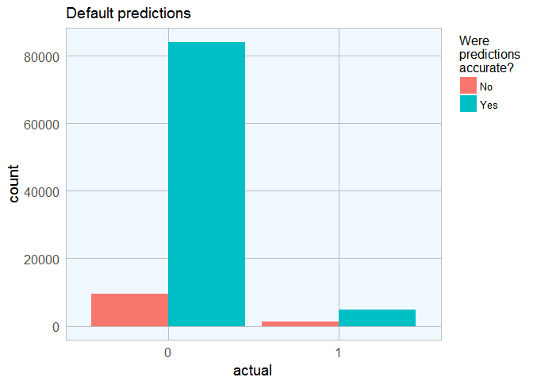

```r
finalRf_predictions %>%
  ggplot(aes(x = actual, fill = accurate)) +
  geom_bar(position = "dodge") +
  my_theme() +
  labs(fill = "Were\npredictions\naccurate?",
       title = "Default predictions")
```

### Summary

Suggested Actions:

1. Feature Engineering
   - How did we categorize missing values? Should we drop columns?
   - Can we create new features from our data? Binning/Differencing/etc.
   - Explore PCA analysis and add weights to our model
2. Sampling Techniques
   - Test different sampling techniques (Over/Under/ROSE) and compare performance
   - Try different cross validation techniques while sampling
3. Complex Models
   - We can pre-train another supervised learning model to feed into our DL to improve performance. We could also test out different models (XGBoost, etc.)
4. Anomaly Detection
   - We are quite close to being an anomoly detection case as we have limited rows and only 6% of one class. If we drop them to less than 1% we could start building an anomoly framework which might more accuractly predict the classes.
5. Gather more data!
   - This can be an expensive option but sometimes the data we have is just not good enough to classify our label.